# Data Visialization

Anna Nesterovich

1February 14th, 2019 г

# Reformat data for plotting

Alaska Department of Fish and Game, Division of Commercial Fisheries. 2017. Daily salmon escapement counts from the OceanAK database, Alaska, 1921-2017. Knowledge Network for Biocomplexity. doi:10.5063/F1S46Q6M.

```r
data_url <- "https://knb.ecoinformatics.org/knb/d1/mn/v2/object/urn%3Auuid%3Af119a05b-bbe7-4aea-93c6-85434dcb1c5e"

#looks for the file on disk first, then downloads
esc <- tryCatch(
    read.csv("data/escapement.csv", stringsAsFactors = FALSE),
    error=function(cond) {
        message(paste("Escapement file does not seem to exist, so get it from the KNB."))
        esc <- read.csv(url(data_url, method = "libcurl"), stringsAsFactors = FALSE)
        return(esc)
    }
)
```

```
## Escapement file does not seem to exist, so get it from the KNB.
```

```r
head(esc)
```

```
##        Location SASAP.Region sampleDate Species DailyCount  Method
## 1 Akalura Creek       Kodiak 1930-05-24 Sockeye          4 Unknown
## 2 Akalura Creek       Kodiak 1930-05-25 Sockeye         10 Unknown
## 3 Akalura Creek       Kodiak 1930-05-26 Sockeye          0 Unknown
## 4 Akalura Creek       Kodiak 1930-05-27 Sockeye          0 Unknown
## 5 Akalura Creek       Kodiak 1930-05-28 Sockeye          0 Unknown
## 6 Akalura Creek       Kodiak 1930-05-29 Sockeye          0 Unknown
##   Latitude Longitude Source
## 1  57.1641 -154.2287   ADFG
## 2  57.1641 -154.2287   ADFG
## 3  57.1641 -154.2287   ADFG
## 4  57.1641 -154.2287   ADFG
## 5  57.1641 -154.2287   ADFG
## 6  57.1641 -154.2287   ADFG
```

```r
esc <- read.csv(url("https://knb.ecoinformatics.org/knb/d1/mn/v2/object/urn%3Auuid%3Af119a05b-bbe7-4aea-93c6-85434dcb1c5e", method="libcurl"), stringsAsFactors=F)
head(esc)
```

```
##        Location SASAP.Region sampleDate Species DailyCount  Method
## 1 Akalura Creek       Kodiak 1930-05-24 Sockeye          4 Unknown
## 2 Akalura Creek       Kodiak 1930-05-25 Sockeye         10 Unknown
## 3 Akalura Creek       Kodiak 1930-05-26 Sockeye          0 Unknown
## 4 Akalura Creek       Kodiak 1930-05-27 Sockeye          0 Unknown
## 5 Akalura Creek       Kodiak 1930-05-28 Sockeye          0 Unknown
## 6 Akalura Creek       Kodiak 1930-05-29 Sockeye          0 Unknown
##   Latitude Longitude Source
## 1  57.1641 -154.2287   ADFG
## 2  57.1641 -154.2287   ADFG
## 3  57.1641 -154.2287   ADFG
## 4  57.1641 -154.2287   ADFG
## 5  57.1641 -154.2287   ADFG
## 6  57.1641 -154.2287   ADFG
```

All the libraries we’ll need

```r
library(dplyr)
```

```r
library(tidyr)
library(ggplot2)
library(scales)
```

- calculate annual escapment by species and region
- filter for just Pacific salmon (Sockeye, Chinook, Coho, Pink, Chum)

annual_esc use functions: gather spread rename mutate select filter group_by summarize arrange separate unite split-apply-combine (region as grouping variable)

```r
#separate for the date to extract year from it
#group_by - we want to group by region and year and species
#summarize - to sum all the dily counts into annual counts for a species
    #in a region for a year
#filter - pull out the species we want (the 5 Pacific ones)
#Species %in% c(...), not the or| thing would be better

annual_esc <- esc %>%
  separate(sampleDate, c("year", "month", "day"), "-", remove=F) %>%
    #if I don't want to ungroup later, I need to do year as numeric here
    group_by(SASAP.Region, Species, year) %>%
    summarize(annualEsc = sum(DailyCount)) %>%
    filter(Species == "Sockeye" | Species == "Chinook" |
               Species =="Coho" | Species =="Pink" | Species=="Chum") %>%
    #need to coerce year to numeric type
    ungroup() %>%
    mutate(year=as.numeric(year))
annual_esc
```

```
## # A tibble: 1,484 x 4
##    SASAP.Region                          Species  year annualEsc
##    <chr>                                 <chr>   <dbl>     <int>
##  1 Alaska Peninsula and Aleutian Islands Chinook  1974      1092
##  2 Alaska Peninsula and Aleutian Islands Chinook  1975      1917
##  3 Alaska Peninsula and Aleutian Islands Chinook  1976      3045
##  4 Alaska Peninsula and Aleutian Islands Chinook  1977      4844
##  5 Alaska Peninsula and Aleutian Islands Chinook  1978      3901
##  6 Alaska Peninsula and Aleutian Islands Chinook  1979     10463
##  7 Alaska Peninsula and Aleutian Islands Chinook  1980      4506
##  8 Alaska Peninsula and Aleutian Islands Chinook  1981      5046
##  9 Alaska Peninsula and Aleutian Islands Chinook  1982      6503
## 10 Alaska Peninsula and Aleutian Islands Chinook  1983     11589
## # ... with 1,474 more rows
```

So now the data is tidy enough and we are going to make some plots

# Generate some static plots

first is the ggplot call with aes stand for aestetics, what you want to add to the plot and how it looks like the second part is geometry, to tell it how to plot your data there, some sort of geom function and there are a lot, we’ll do bar plot color is the outline, fill the color within, color goes not in the aes, not a variable in the dataset, it goes to geom

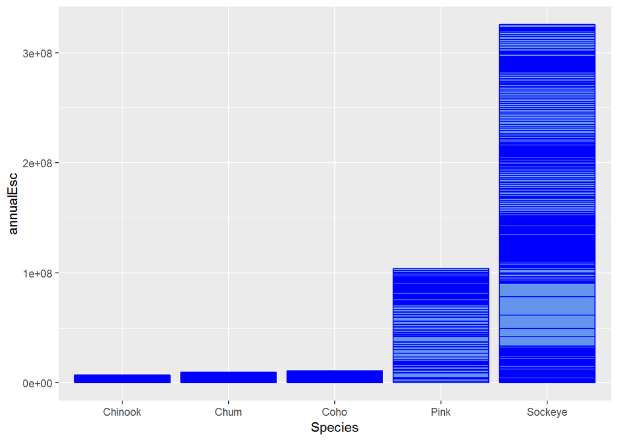

```r
ggplot(annual_esc, aes(x = Species, y = annualEsc)) +
    geom_col(color="blue", fill="cornflowerblue")
```

Can put almost everything into geom, when you say want different geometries on the the same plot (bar and a line say), or two diff datasets on the same plot

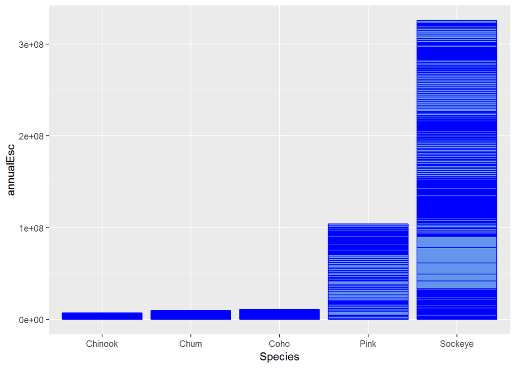

```r
ggplot(annual_esc) +
    geom_col(mapping=aes(x = Species, y = annualEsc), color="blue", fill="cornflowerblue")
```

scale_fill_manual can specify colors in pairs there is a good cheatsheet for ggplot vizulation in help

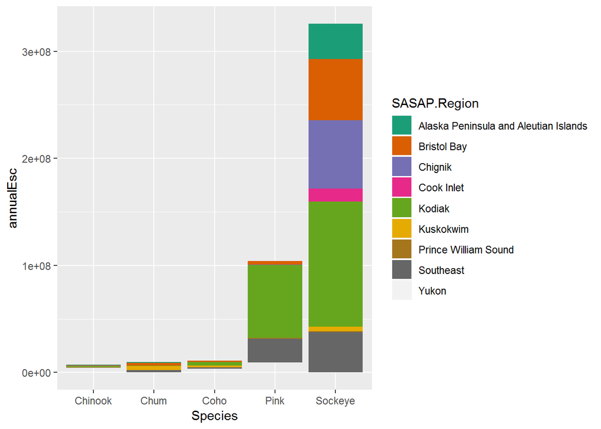

```r
ggplot(annual_esc, aes(x = Species, y = annualEsc, fill=SASAP.Region)) +
    scale_fill_brewer(palette="Dark2") +
    geom_col()
```